# HW-3

Author

Gowri

```r
#setup
library(readr)
library(dplyr)
library(tidyr)
library(ggplot2)
library(tidytext)
library(stringr)
library(knitr)
library(textdata)
library(tidytext)
```

Question 1

(15 points) How many abstracts are associated with each search term? Tokenize the abstracts and count the number of each token. Do you see anything interesting? What are the 5 most common tokens for each search term?

```r
pub <- read_csv("~/Downloads/pubmed.csv")
str(pub)
```

```
spc_tbl_ [3,241 × 2] (S3: spec_tbl_df/tbl_df/tbl/data.frame)
 $ abstract: chr [1:3241] "Background and aims: Many patients with coronavirus disease 2019 (COVID-19) have underlying cardiovascular (CV)"| __truncated__ "Introduction: Contradictory data have been reported on the incidence of stroke in patients with COVID-19 and th"| __truncated__ "This article ai…
 $ term    : chr [1:3241] "covid" "covid" "covid" "covid" ...
 - attr(*, "spec")=
  .. cols(
  ..   abstract = col_character(),
  ..   term = col_character()
  .. )
 - attr(*, "problems")=<externalptr>
```

```r
head(pub)
```

```
# A tibble: 6 × 2
  abstract                                                                 term
  <chr>                                                                    <chr>
1 "Background and aims: Many patients with coronavirus disease 2019 (COVI… covid
2 "Introduction: Contradictory data have been reported on the incidence o… covid
3 "This article aims at collecting all information needed for dentists re… covid
4 "OBJECTIVE. The objective of our study was to determine the misdiagnosi… covid
5 "Background: Much of the focus regarding the global pandemic of coronav… covid
6 "The World Health Organization (WHO) has issued a warning that, althoug… covid
```

```r
# how many abstracts are associated wiht each search term

abs_counts <- pub %>%
  count(term, name = "n_abstracts") %>%
  arrange(desc(n_abstracts))

abs_counts
```

```
# A tibble: 5 × 2
  term            n_abstracts
  <chr>                 <int>
1 covid                   981
2 prostate cancer         787
3 preeclampsia            780
4 cystic fibrosis         376
5 meningitis              317
```

```r
#Tokenizing the abstracts and counting the number for each tocken
tokens_original <- pub %>%
  select(term, abstract) %>%     # keeping only the two useful columns
  unnest_tokens(word, abstract)  # spliting each abstract into words

# Showing first few rows and total number of tokens
head(tokens_original)
```

```
# A tibble: 6 × 2
  term  word
  <chr> <chr>
1 covid background
2 covid and
3 covid aims
4 covid many
5 covid patients
6 covid with
```

```r
nrow(tokens_original)
```

```
[1] 555151
```

```r
# Counting how many times each token (word) appears overall
token_counts <- tokens_original %>%
  count(word, sort = TRUE)

# Showing the first few most common tokens
head(token_counts, 10)
```

```
# A tibble: 10 × 2
   word      n
   <chr> <int>
 1 the   28126
 2 of    24760
 3 and   19993
 4 in    14653
 5 to    10920
 6 a      8245
 7 with   8038
 8 covid  7275
 9 19     7080
10 is     5649
```

```r
# Counting how many times each token appears within each search term
top5_raw_by_term <- tokens_original %>%
  count(term, word, sort = TRUE) %>%        # counting words per term
  group_by(term) %>%                        # grouping by search term
  slice_max(n, n = 5, with_ties = FALSE) %>% # keepiong top 5 tokens per term
  arrange(term, desc(n))                     # arranging for readability

# Showing the results
knitr::kable(top5_raw_by_term)
```

| term | word | n |
| --- | --- | --- |
| covid | the | 9741 |
| covid | of | 7668 |
| covid | covid | 7275 |
| covid | 19 | 7035 |
| covid | and | 6861 |
| cystic fibrosis | the | 2677 |
| cystic fibrosis | of | 2304 |
| cystic fibrosis | and | 1777 |
| cystic fibrosis | in | 1497 |
| cystic fibrosis | to | 1011 |
| meningitis | the | 2489 |
| meningitis | of | 2269 |
| meningitis | and | 1683 |
| meningitis | in | 1322 |
| meningitis | a | 830 |
| preeclampsia | the | 7119 |
| preeclampsia | of | 6837 |
| preeclampsia | and | 5255 |
| preeclampsia | in | 3869 |
| preeclampsia | to | 2651 |
| prostate cancer | the | 6100 |
| prostate cancer | of | 5682 |
| prostate cancer | and | 4417 |
| prostate cancer | cancer | 3840 |
| prostate cancer | prostate | 3832 |

Answer:  
The dataset has a total of 3,241 abstracts from five different search terms. The largest number of abstracts came from COVID (981), followed by prostate cancer (787) and preeclampsia (780). There were fewer abstracts for cystic fibrosis(376) and meningitis (317).

After tokenizing all the abstracts, there were around 555,000 total tokens. The most common words overall were basic English words like *the*, *of*, and *and*, which appear in almost every sentence.

Even before removing stop words, some topic-specific words like *covid*, *19*, *cancer*, and *prostate* showed up frequently. This suggests that some abstracts repeat key disease terms more often, while others use more general language.

Overall, this step shows why removing stop words is important — it helps focus on the **s**cientific and meaningful words instead of common grammatical ones.

Question 2

(15 points) Does removing stop words change what tokens appear as the most frequent? What are the 5 most common tokens for each search term after removing stop words?

```r
# Loading the table of common English words (the, of, and, in, to, ...)
data("stop_words")
head(stop_words)
```

```
# A tibble: 6 × 2
  word      lexicon
  <chr>     <chr>
1 a         SMART
2 a's       SMART
3 able      SMART
4 about     SMART
5 above     SMART
6 according SMART
```

```r
# Removeing any token whose word appears in stop_words
tokens_new <- tokens_original %>%
  filter(!word %in% stop_words$word)

#5 top most common tocken for each serach term after removing the stop words
top5_clean_by_term <- tokens_new %>%
  count(term, word, sort = TRUE) %>%
  group_by(term) %>%
  arrange(desc(n), .by_group = TRUE) %>%
  filter(row_number() <= 5)

knitr::kable(top5_clean_by_term)
```

| term | word | n |
| --- | --- | --- |
| covid | covid | 7275 |
| covid | 19 | 7035 |
| covid | patients | 2293 |
| covid | disease | 943 |
| covid | pandemic | 800 |
| cystic fibrosis | fibrosis | 867 |
| cystic fibrosis | cystic | 862 |
| cystic fibrosis | cf | 625 |
| cystic fibrosis | patients | 586 |
| cystic fibrosis | disease | 400 |
| meningitis | patients | 446 |
| meningitis | meningitis | 429 |
| meningitis | meningeal | 219 |
| meningitis | csf | 206 |
| meningitis | clinical | 187 |
| preeclampsia | pre | 2038 |
| preeclampsia | eclampsia | 2005 |
| preeclampsia | preeclampsia | 1863 |
| preeclampsia | women | 1196 |
| preeclampsia | pregnancy | 969 |
| prostate cancer | cancer | 3840 |
| prostate cancer | prostate | 3832 |
| prostate cancer | patients | 934 |
| prostate cancer | treatment | 926 |
| prostate cancer | disease | 652 |

```r
top5_clean_by_term %>%
  group_by(term) %>%
  summarise(n_rows = n())
```

```
# A tibble: 5 × 2
  term            n_rows
  <chr>            <int>
1 covid                5
2 cystic fibrosis      5
3 meningitis           5
4 preeclampsia         5
5 prostate cancer      5
```

Answer:  
Removing stop words completely changed which tokens appeared most frequently.  
Before cleaning, the top tokens were common English words such as *the*, *of*, and *and*, which appear in almost every sentence.  
After removing these stop words, the most common tokens became much more topic-specific.

• **COVID:** *covid*, *19*, *patients*, *disease*, *pandemic*  
• **Prostate cancer:** *cancer*, *prostate*, *patients*, *treatment*, *disease*  
• **Cystic fibrosis:** *fibrosis*, *cystic*, *cf*, *patients*, *disease*  
• **Preeclampsia:** *pre*, *eclampsia*, *preeclampsia*, *women*, *pregnancy*  
• **Meningitis:** *meningitis*, *meningeal*, *csf*, *clinical*, *patients*

These results show that stop-word removal reveals the key medical terms for each topic, making the frequency counts more meaningful and specific to each disease.

Question 3

Tokenize the abstracts into bigrams. Find the 10 most common bigrams and visualize them.

```r
# Createing bigrams (two-word sequences)
bigrams <- pub %>%
  select(term, abstract) %>%
  unnest_ngrams(bigram, abstract, n = 2)

# Spliting each bigram into two separate words
bigrams_separated <- bigrams %>%
  separate(bigram, into = c("word1", "word2"), sep = " ", remove = FALSE)

# Removeing bigrams that contain stop words
bigrams_clean <- bigrams_separated %>%
  filter(!word1 %in% stop_words$word & !word2 %in% stop_words$word)

# Counting bigrams and keep the top 10 overall
top10_bigrams <- bigrams_clean %>%
  count(bigram, sort = TRUE) %>%
  head(10)

knitr::kable(top10_bigrams)
```

| bigram | n |
| --- | --- |
| covid 19 | 6969 |
| prostate cancer | 3222 |
| pre eclampsia | 1854 |
| cystic fibrosis | 860 |
| 19 patients | 447 |
| 19 pandemic | 419 |
| coronavirus disease | 361 |
| 95 ci | 322 |
| sars cov | 317 |
| cov 2 | 299 |

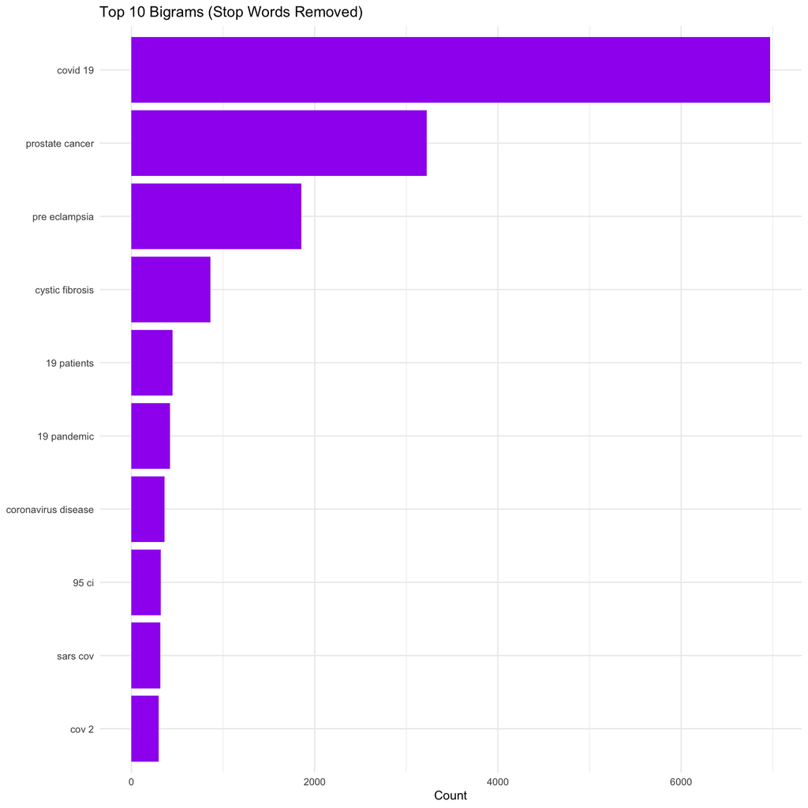

```r
# Visualize the top 10 bigrams
ggplot(top10_bigrams, aes(x = n, y = reorder(bigram, n))) +
  geom_col(fill = "purple") +
  labs(x = "Count", y = NULL, title = "Top 10 Bigrams (Stop Words Removed)") +
  theme_minimal()
```

**Question 4**

Calculate the TF-IDF value for each word-search term combination (here you want the search term to be the “document”). What are the 5 tokens from each search term with the highest TF-IDF value? How are the results different from the answers you got in Question 1?

```r
# Counting words within each term
term_word_counts <- tokens_new %>%
  count(term, word, sort = TRUE)

# Computing TF-IDF correctly
tfidf <- term_word_counts %>%
  bind_tf_idf(word, term, n)

# Showing top-5 terms
top5_tfidf_by_term <- tfidf %>%
  group_by(term) %>%
  arrange(desc(tf_idf), .by_group = TRUE) %>%
  filter(row_number() <= 5) %>%
  select(term, word, tf_idf)

knitr::kable(top5_tfidf_by_term, digits = 4)
```

| term | word | tf_idf |
| --- | --- | --- |
| covid | covid | 0.1041 |
| covid | pandemic | 0.0114 |
| covid | coronavirus | 0.0093 |
| covid | sars | 0.0053 |
| covid | cov | 0.0048 |
| cystic fibrosis | cf | 0.0215 |
| cystic fibrosis | fibrosis | 0.0166 |
| cystic fibrosis | cystic | 0.0165 |
| cystic fibrosis | cftr | 0.0052 |
| cystic fibrosis | sweat | 0.0050 |
| meningitis | meningitis | 0.0264 |
| meningitis | meningeal | 0.0135 |
| meningitis | pachymeningitis | 0.0092 |
| meningitis | csf | 0.0072 |
| meningitis | meninges | 0.0065 |
| preeclampsia | eclampsia | 0.0411 |
| preeclampsia | preeclampsia | 0.0382 |
| preeclampsia | pregnancy | 0.0063 |
| preeclampsia | maternal | 0.0052 |
| preeclampsia | gestational | 0.0039 |
| prostate cancer | prostate | 0.0906 |
| prostate cancer | androgen | 0.0072 |
| prostate cancer | psa | 0.0067 |
| prostate cancer | prostatectomy | 0.0051 |
| prostate cancer | castration | 0.0035 |

**Answer:**

In this step, TF-IDF (Term Frequency – Inverse Document Frequency) method was used to find the most important words for each search term.  
Here, each search term (for example *covid*, *prostate cancer*, *preeclampsia*, *cystic fibrosis*, and *meningitis*) was treated as one big document made up of all its abstracts.  
TF-IDF compares how often a word appears within one search term to how rarely it appears in the other terms, giving higher scores to words that are unique to a particular topic.

After calculating TF-IDF, the five tokens with the highest values for each search term were:

- **COVID:** *covid*, *pandemic*, *coronavirus*, *sars*, *cov*
- **Prostate Cancer:** *prostate*, *androgen*, *psa*, *prostatectomy*, *castration*
- **Preeclampsia:** *eclampsia*, *preeclampsia*, *pregnancy*, *maternal*, *gestational*
- **Cystic Fibrosis:** *cf*, *fibrosis*, *cystic*, *cftr*, *sweat*
- **Meningitis:** *meningitis*, *meningeal*, *pachymeningitis*, *csf*, *meninges*

These words have the highest TF-IDF scores because they appear frequently in their own group of abstracts but are uncommon in the others.  
For instance, *covid* and *coronavirus* appear almost only in the COVID papers, and *prostate* and *psa* mostly appear in prostate-cancer papers.

Word frequency shows which words appear the most, while TF-IDF shows which words are special to each topic. This helps each disease group stand out with the words that describe it best.

**SENTIMENT ANALYSIS**

**Question 5**

Perform a sentiment analysis using the NRC lexicon. What is the most common sentiment for each search term? What if you remove `"positive"` and `"negative"` from the list?

```r
# Loading the NRC sentiment lexicon
nrc <- get_sentiments("nrc")

# Joining the cleaned tokens with the NRC lexicon
tokens_nrc <- tokens_original %>%
  inner_join(nrc, by = "word")
# Counting how many times each sentiment appears within each search term
sentiment_counts <- tokens_nrc %>%
  count(term, sentiment, sort = TRUE)

# Find the most common sentiment for each term
top_sentiment <- sentiment_counts %>%
  group_by(term) %>%
  slice_max(n, n = 1)

knitr::kable(top_sentiment)
```

| term | sentiment | n |
| --- | --- | --- |
| covid | positive | 9874 |
| cystic fibrosis | positive | 2747 |
| meningitis | negative | 2109 |
| preeclampsia | positive | 8014 |
| prostate cancer | negative | 8918 |

```r
# Removeing the  sentiments "positive" and "negative"
sentiment_counts_noPN <- tokens_nrc %>%
  filter(!sentiment %in% c("positive", "negative")) %>%  # droping these two labels
  count(term, sentiment, sort = TRUE)                    # counting emotions for each search term

# Finding the most common emotion per term
top_sentiment_noPN <- sentiment_counts_noPN %>%
  group_by(term) %>%
  arrange(desc(n)) %>%
  filter(row_number() == 1) %>%   # keeping only the top one per term
  ungroup()

# Viewing the result as a clean table
knitr::kable(top_sentiment_noPN)
```

| term | sentiment | n |
| --- | --- | --- |
| prostate cancer | fear | 8118 |
| covid | fear | 7730 |
| preeclampsia | anticipation | 4780 |
| cystic fibrosis | disgust | 1714 |
| meningitis | fear | 1510 |

**ANSWER:**  
The NRC sentiment lexicon was used to study the emotions found in the abstracts for each search term. When all sentiments were included, COVID, cystic fibrosis, and preeclampsia mostly contained positive words, while prostate cancer and meningitis showed more negative words. After removing the general categories “positive” and “negative,” the main emotions became clearer. The most common feeling in the COVID, prostate cancer, and meningitis abstracts was fear, while preeclampsia showed anticipation and cystic fibrosis showed disgust. Overall, fear was the most dominant emotion across the topics.

**6.Now perform a sentiment analysis using the AFINN lexicon to get an average positivity score for each abstract (hint: you may want to create a variable that indexes, or counts, the abstracts). Create a visualization that shows these scores grouped by search term. Are any search terms noticeably different from the others?**

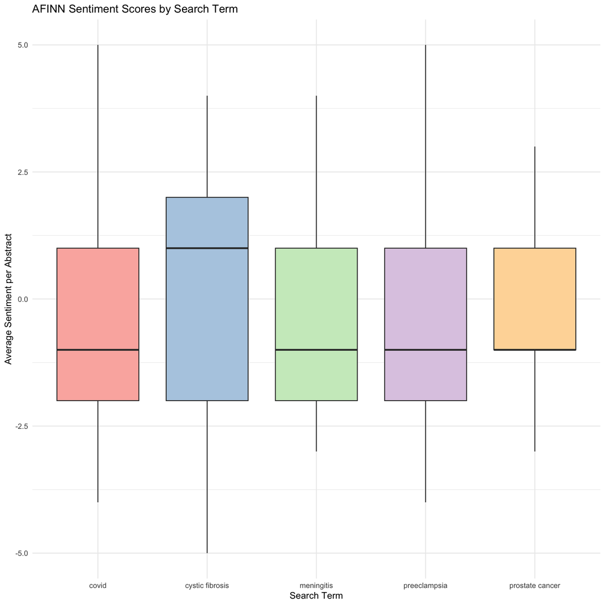

```r
# Loading AFINN sentiment dictionary
afinn <- get_sentiments("afinn")

# Joining cleaned tokens with AFINN (adds sentiment score to matching words)
tokens_afinn <- tokens_new %>%
  inner_join(afinn, by = "word")

#Addign a row number to each token

tokens_afinn <- tokens_afinn %>%
  group_by(term) %>%
  mutate(abstract_id = row_number()) %>%
  ungroup()

#calculating average sentiment score per abstratc

afinn_scores <- tokens_afinn %>%
  group_by(term, abstract_id) %>%
  summarize(avg_sentiment = mean(value, na.rm = TRUE)) %>%
  ungroup()
#visulaizing the average sentimnt by serach word

ggplot(afinn_scores, aes(x = term, y = avg_sentiment, fill = term)) +
  geom_boxplot(show.legend = FALSE) +
  scale_fill_brewer(palette = "Pastel1") +
  labs(
    title = "AFINN Sentiment Scores by Search Term",
    x = "Search Term",
    y = "Average Sentiment per Abstract"
  ) +
  theme_minimal()
```

**ANSWER:**

COVID, meningitis, preeclampsia, and prostate cancer all showed more negative averages, suggesting their abstracts emphasize illness, risk, or complications. Cystic fibrosis, on the other hand, had a more positive average sentiment, which may indicate that its papers discuss treatments and management strategies more often. Overall, cystic fibrosis was noticeably different from the other search terms, it had higher, less negative scores, showing a more hopeful or treatment-focused tone. In contrast, the other four topics were more negative, reflecting their focus on severe or life-threatening conditions.